# Predicting Housing Prices

Sosnovskikh, Anastasia

April 2021

# Load Data

Load the packages.

### Helpful Functions

Functions to get a list of columns.

```r
get_CATEGORICAL_features_list <- function(df){
  cat_vars <- colnames(df)[grepl('factor|logical|character',sapply(df,class))]
}

get_CONTINIOUS_features_list <- function(df){
  df %>% select(-get_CATEGORICAL_features_list(df)) %>% colnames()
}
```

# EDA

Read in the data.

```r
input_train <- read.csv('train.csv', header=T, row.names='id')
input_test <- read.csv('test.csv', header=T, row.names='id')
```

#### (0) Check the dimensions.

```r
input_train %>% dim()
```

```
## [1] 1400   16
```

```r
input_test %>% dim()
```

```
## [1] 600  16
```

#### (1) Get a glimpse of the data.

```r
input_train %>% glimpse()
```

```
## Rows: 1,400
## Columns: 16
## $ price          <dbl> 141120.01, 133554.98, 736087.06, 114542.15, 152769.22, ~
## $ desc           <chr> "SINGLE FAMILY", "SINGLE FAMILY", "SINGLE FAMILY", "SIN~
## $ numstories     <dbl> 1.0, 1.0, 1.0, 1.5, 1.0, 1.0, 1.0, 2.0, 1.5, 1.0, 1.0, ~
## $ yearbuilt      <int> 1952, 1951, 1959, 1945, 1954, 1957, 1954, 1927, 1950, 1~
## $ exteriorfinish <chr> "Brick", "Brick", "Brick", "Brick", "Brick", "Brick", "~
## $ rooftype       <chr> "SHINGLE", "SHINGLE", "SLATE", "SHINGLE", "SHINGLE", "S~
## $ basement       <int> 1, 1, 1, 0, 0, 1, 0, 0, 0, 1, 1, 1, 1, 1, 1, 1, 0, 1, 0~
## $ totalrooms     <int> 7, 5, 9, 6, 6, 6, 8, 9, 9, 7, 6, 12, 7, 6, 8, 7, 6, 6, ~
## $ bedrooms       <int> 3, 3, 4, 3, 2, 2, 3, 4, 4, 3, 3, 6, 3, 3, 4, 3, 3, 3, 4~
## $ bathrooms      <dbl> 1.5, 1.5, 3.5, 1.0, 1.0, 1.5, 2.5, 1.0, 2.0, 1.5, 2.5, ~
## $ fireplaces     <int> 1, 2, NA, NA, NA, 0, NA, NA, NA, 0, 1, 2, 0, 0, 1, 1, N~
## $ sqft           <int> 1443, 1285, 2607, 1321, 1200, 1328, 2246, 2028, 2031, 1~
## $ lotarea        <dbl> 11010.00, 165964.00, 34848.00, 7517.25, 6098.40, 6428.0~
## $ state          <chr> "PA", "PA", "VA", "VA", "VA", "PA", "VA", "VA", "VA", "~
## $ zipcode        <int> 15025, 15003, 23226, 23224, 23231, 15030, 23222, 23227,~
## $ AvgIncome      <int> 60669, 37868, 50519, 27132, 43600, 50313, 29570, 36568,~
```

```r
input_test %>% glimpse()
```

```
## Rows: 600
## Columns: 16
## $ price          <lgl> NA, NA, NA, NA, NA, NA, NA, NA, NA, NA, NA, NA, NA, NA,~
## $ desc           <chr> "SINGLE FAMILY", "SINGLE FAMILY", "SINGLE FAMILY", "SIN~
## $ numstories     <dbl> 2.00, 2.00, 1.50, 2.00, 2.00, 2.00, 1.00, 2.00, 2.00, 1~
## $ yearbuilt      <int> 1936, 1941, 1932, 1998, 1923, 1910, 2013, 1957, 1923, 1~
## $ exteriorfinish <chr> "Stone", "Brick", "Stucco", "Brick", "Brick", "Brick", ~
## $ rooftype       <chr> "SLATE", "SLATE", "SLATE", "SLATE", "METAL", "METAL", "~
## $ basement       <int> 1, 0, 0, 1, 0, 0, 0, 1, 0, 1, 1, 0, 0, 0, 0, 0, 1, 1, 1~
## $ totalrooms     <int> 9, 11, 7, 12, 6, 6, 5, 12, 8, 8, 10, 7, 6, 8, 7, 6, 6, ~
## $ bedrooms       <int> 4, 3, 3, 5, 3, 3, 2, 5, 3, 4, 4, 3, 3, 4, 3, 3, 2, 2, 3~
## $ bathrooms      <dbl> 5.0, 3.5, 1.0, 7.5, 1.0, 2.0, 2.5, 5.0, 2.0, 3.5, 4.0, ~
## $ fireplaces     <int> 2, NA, NA, 2, NA, NA, 0, NA, NA, 0, NA, NA, NA, NA, NA,~
## $ sqft           <int> 5980, 3266, 1839, 12150, 1602, 2010, 2340, 4739, 1479, ~
## $ lotarea        <dbl> 17710.00, 38912.00, 5280.00, 193711.00, 2255.00, 1779.0~
## $ state          <chr> "PA", "VA", "VA", "PA", "VA", "VA", "PA", "VA", "VA", "~
## $ zipcode        <int> 15243, 23225, 23227, 15044, 23220, 23220, 15025, 23226,~
## $ AvgIncome      <int> 60717, 35101, 36568, 95289, 26557, 26557, 60669, 50519,~
```

Get a summary of the variables.

```r
input_train %>% summary()
```

```
##      price             desc             numstories      yearbuilt
##  Min.   :  35847   Length:1400        Min.   :1.000   Min.   :1805
##  1st Qu.: 139575   Class :character   1st Qu.:1.000   1st Qu.:1922
##  Median : 267905   Mode  :character   Median :2.000   Median :1940
##  Mean   : 343143                      Mean   :1.691   Mean   :1944
##  3rd Qu.: 426548                      3rd Qu.:2.000   3rd Qu.:1960
##  Max.   :3990701                      Max.   :3.000   Max.   :2017
##
##  exteriorfinish       rooftype            basement        totalrooms
##  Length:1400        Length:1400        Min.   :0.0000   Min.   : 3.000
##  Class :character   Class :character   1st Qu.:0.0000   1st Qu.: 6.000
##  Mode  :character   Mode  :character   Median :1.0000   Median : 7.000
##                                        Mean   :0.5607   Mean   : 7.515
##                                        3rd Qu.:1.0000   3rd Qu.: 9.000
##                                        Max.   :1.0000   Max.   :23.000
##
##     bedrooms       bathrooms        fireplaces          sqft
##  Min.   : 1.00   Min.   : 1.000   Min.   :0.0000   Min.   :  475
##  1st Qu.: 3.00   1st Qu.: 1.500   1st Qu.:0.0000   1st Qu.: 1349
##  Median : 3.00   Median : 2.000   Median :0.0000   Median : 1831
##  Mean   : 3.36   Mean   : 2.233   Mean   :0.6101   Mean   : 2201
##  3rd Qu.: 4.00   3rd Qu.: 2.500   3rd Qu.:1.0000   3rd Qu.: 2573
##  Max.   :12.00   Max.   :10.000   Max.   :5.0000   Max.   :15872
##                                   NA's   :687
##     lotarea           state              zipcode        AvgIncome
##  Min.   :      0   Length:1400        Min.   :15003   Min.   :11306
##  1st Qu.:   3794   Class :character   1st Qu.:15216   1st Qu.:29570
##  Median :   7744   Mode  :character   Median :15332   Median :39943
##  Mean   :  32528                      Mean   :19120   Mean   :43911
##  3rd Qu.:  16166                      3rd Qu.:23222   3rd Qu.:55239
##  Max.   :3820212                      Max.   :23235   Max.   :95289
##
```

```r
input_test %>% summary()
```

```
##   price             desc             numstories      yearbuilt
##  Mode:logical   Length:600         Min.   :1.000   Min.   :1720
##  NA's:600       Class :character   1st Qu.:1.000   1st Qu.:1920
##                 Mode  :character   Median :2.000   Median :1940
##                                    Mean   :1.689   Mean   :1941
##                                    3rd Qu.:2.000   3rd Qu.:1960
##                                    Max.   :3.000   Max.   :2017
##
##  exteriorfinish       rooftype            basement       totalrooms
##  Length:600         Length:600         Min.   :0.000   Min.   : 2.000
##  Class :character   Class :character   1st Qu.:0.000   1st Qu.: 6.000
##  Mode  :character   Mode  :character   Median :1.000   Median : 7.000
##                                        Mean   :0.525   Mean   : 7.322
##                                        3rd Qu.:1.000   3rd Qu.: 9.000
##                                        Max.   :1.000   Max.   :16.000
##
##     bedrooms       bathrooms      fireplaces         sqft
##  Min.   :1.000   Min.   :1.00   Min.   :0.000   Min.   :  437
##  1st Qu.:3.000   1st Qu.:1.00   1st Qu.:0.000   1st Qu.: 1308
##  Median :3.000   Median :2.00   Median :0.000   Median : 1772
##  Mean   :3.303   Mean   :2.19   Mean   :0.561   Mean   : 2158
##  3rd Qu.:4.000   3rd Qu.:2.50   3rd Qu.:1.000   3rd Qu.: 2684
##  Max.   :8.000   Max.   :7.50   Max.   :3.000   Max.   :12150
##                                 NA's   :313
##     lotarea           state              zipcode        AvgIncome
##  Min.   :      0   Length:600         Min.   :15003   Min.   :11306
##  1st Qu.:   3461   Class :character   1st Qu.:15220   1st Qu.:29570
##  Median :   7204   Mode  :character   Median :23220   Median :39943
##  Mean   :  21791                      Mean   :19371   Mean   :42943
##  3rd Qu.:  16202                      3rd Qu.:23222   3rd Qu.:51643
##  Max.   :1242593                      Max.   :23235   Max.   :95289
##
```

#### (2) Check for **missing data**.

```r
input_train %>% purrr::map_dbl(~sum(is.na(.)))
```

```
##          price           desc     numstories      yearbuilt exteriorfinish
##              0              0              0              0              0
##       rooftype       basement     totalrooms       bedrooms      bathrooms
##              0              0              0              0              0
##     fireplaces           sqft        lotarea          state        zipcode
##            687              0              0              0              0
##      AvgIncome
##              0
```

```r
input_test %>% purrr::map_dbl(~sum(is.na(.)))
```

```
##          price           desc     numstories      yearbuilt exteriorfinish
##            600              0              0              0              0
##       rooftype       basement     totalrooms       bedrooms      bathrooms
##              0              0              0              0              0
##     fireplaces           sqft        lotarea          state        zipcode
##            313              0              0              0              0
##      AvgIncome
##              0
```

Display missing data.

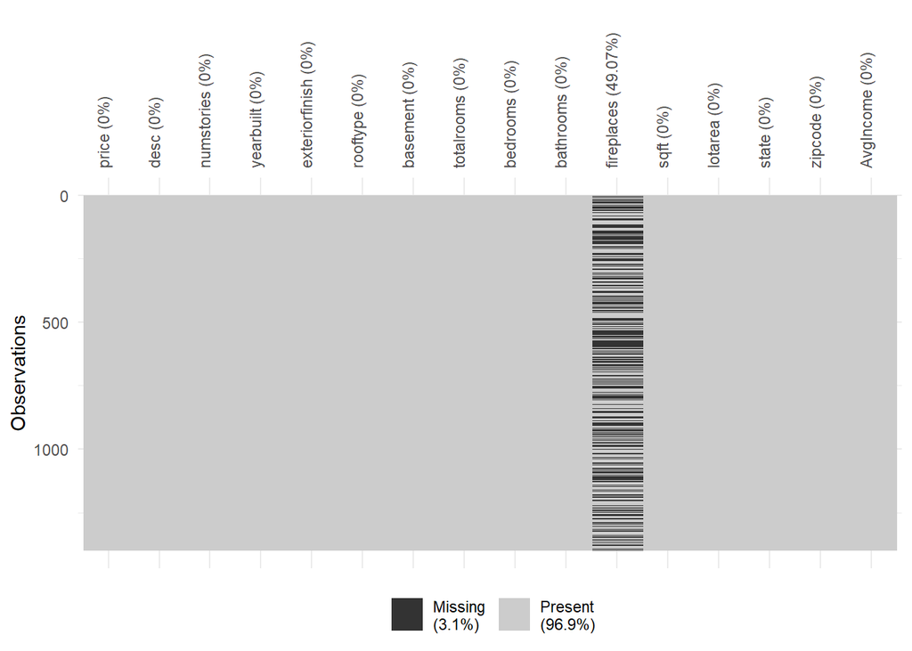

```r
input_train %>%
  visdat::vis_miss() +
  theme(axis.text.x = element_text(angle = 90))
```

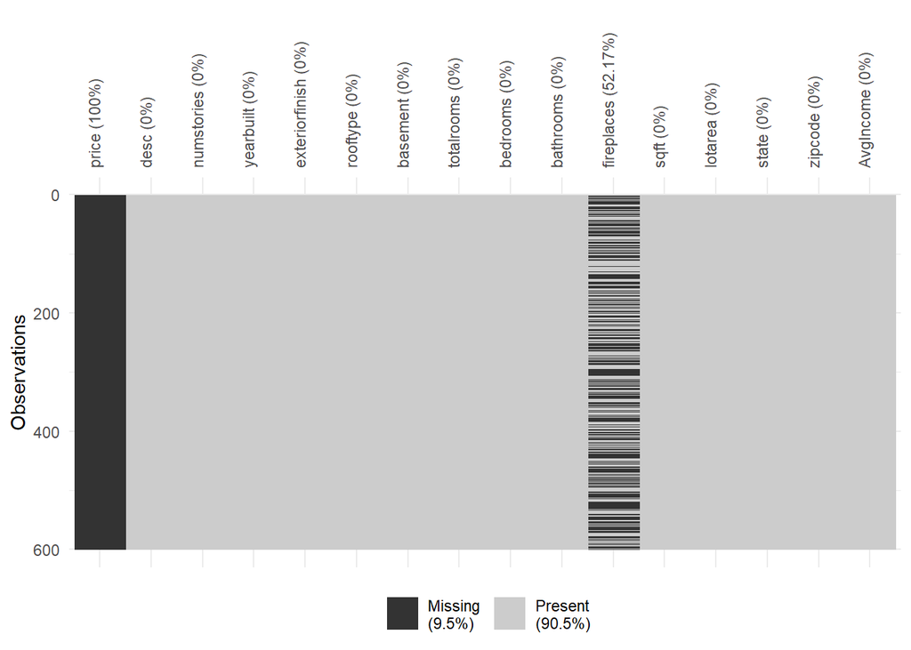

```r
input_test %>%
  visdat::vis_miss() +
  theme(axis.text.x = element_text(angle = 90))
```

*`fireplaces` has the most missing data.*

*Almost half of the data is missing for `fireplaces`. By getting rid of the observations completely I will lose a lot of data and to set some default value might be misleading because it is a big proportion of data. Therefore, I might not want to use `fireplaces` to make predictions.*

#### (3) Check for variables with **near-zero variance**.

```r
input_train %>% nearZeroVar()
```

```
## integer(0)
```

```r
input_test %>% nearZeroVar() # price only
```

```
## [1] 1
```

*There are no variables with a zero variance. Thus, do not need to exclude any variables.*

#### (4) Check **unique**.

Check the number of uniqu variables.

```r
sapply(input_train, n_distinct)
```

```
##          price           desc     numstories      yearbuilt exteriorfinish
##           1400              5              8            139              6
##       rooftype       basement     totalrooms       bedrooms      bathrooms
##              4              2             18              9             18
##     fireplaces           sqft        lotarea          state        zipcode
##              7           1018           1103              2             45
##      AvgIncome
##             45
```

```r
sapply(input_test, n_distinct)
```

```
##          price           desc     numstories      yearbuilt exteriorfinish
##              1              5              9            125              6
##       rooftype       basement     totalrooms       bedrooms      bathrooms
##              4              2             15              8             14
##     fireplaces           sqft        lotarea          state        zipcode
##              5            506            485              2             43
##      AvgIncome
##             43
```

Check the levels.

```r
f <- function(df){
  list(unique(df))
}
```

```r
sapply(input_train[, !names(input_train) %in% c('id', 'price', 'yearbuild', 'sqft', 'lotarea')], f)
```

```
## $desc
## [1] "SINGLE FAMILY" "ROWHOUSE"      "CONDOMINIUM"   "MULTI-FAMILY"
## [5] "MOBILE HOME"
##
## $numstories
## [1] 1.00 1.50 2.00 2.50 3.00 1.80 1.75 1.90
##
## $yearbuilt
##   [1] 1952 1951 1959 1945 1954 1957 1927 1950 1961 1990 1956 1964 1960 1910 1900
##  [16] 1953 2000 1965 1993 1958 1937 1978 1940 1994 1924 1926 2001 1919 1920 1949
##  [31] 1955 1936 1928 1962 1931 1923 1887 1973 1853 1925 1890 1915 1929 1935 1976
##  [46] 1946 2002 2005 1913 1911 2004 1930 2003 1918 1880 2013 1932 1989 1941 1998
##  [61] 1997 1855 2011 1969 1909 1999 2008 1967 1922 1896 1977 2015 1914 1988 1938
##  [76] 1942 2006 2014 1948 2016 1939 1933 1991 1966 1921 1905 1805 1860 2017 1996
##  [91] 1984 1970 1882 1934 1917 1893 1972 1987 1980 1992 1963 1947 1912 2012 1894
## [106] 1995 1885 1975 1850 1986 1971 1903 2010 1916 1906 1983 1968 1849 1902 1895
## [121] 2007 1979 1944 2009 1858 1832 1856 1901 1886 1982 1840 1870 1891 1846 1904
## [136] 1907 1835 1848 1881
##
## $exteriorfinish
## [1] "Brick"    "Frame"    "Stucco"   "Stone"    "Concrete" "Log"
##
## $rooftype
## [1] "SHINGLE" "SLATE"   "METAL"   "ROLL"
##
## $basement
## [1] 1 0
##
## $totalrooms
##  [1]  7  5  9  6  8 12 11 10  3 23  4 13 14 16 15 19 18 20
##
## $bedrooms
## [1]  3  4  2  6  5  1  8  7 12
##
## $bathrooms
##  [1]  1.5  3.5  1.0  2.5  2.0  4.0  3.0  6.0  4.5  5.5  5.0  6.5  7.0  8.0  8.5
## [16]  9.0 10.0  7.5
##
## $fireplaces
## [1]  1  2 NA  0  3  4  5
##
## $state
## [1] "PA" "VA"
##
## $zipcode
##  [1] 15025 15003 23226 23224 23231 15030 23222 23227 15243 15037 15238 15236
## [13] 15235 23223 15213 15237 15212 23225 23221 23220 23235 15228 15044 15014
## [25] 15224 15026 15225 15215 23230 15332 15227 15214 15226 15216 15223 15220
## [37] 15034 15005 15241 15218 23234 23219 15222 15219 15031
##
## $AvgIncome
##  [1] 60669 37868 50519 27132 43600 50313 29570 36568 60717 55863 67370 46913
## [13] 41367 27936 18473 55016 26712 35101 39943 26557 56989 58440 95289 42500
## [25] 22880 69387 30625 43750 36083 62875 38439 30725 37889 39526 33724 44018
## [37] 57850 64427 85102 35983 40522 11306 18598 14399 55031
```

```r
sapply(input_test[, !names(input_test) %in%  c('id', 'price', 'yearbuild', 'sqft', 'lotarea')], f)
```

```
## $desc
## [1] "SINGLE FAMILY" "CONDOMINIUM"   "MULTI-FAMILY"  "ROWHOUSE"
## [5] "MOBILE HOME"
##
## $numstories
## [1] 2.00 1.50 1.00 1.75 2.50 3.00 1.80 2.80 1.70
##
## $yearbuilt
##   [1] 1936 1941 1932 1998 1923 1910 2013 1957 1964 1949 1921 1956 1922 1951 1969
##  [16] 1925 1962 2005 1918 1926 1939 2007 1960 1920 1955 1958 1950 1928 1930 1972
##  [31] 1900 1966 2006 1983 2001 1915 1912 1929 1948 1890 1940 1988 1959 1908 1924
##  [46] 1965 1927 1968 1952 1992 1942 1970 1994 1954 1905 2000 1985 1953 1967 1989
##  [61] 1935 1938 1978 1961 1947 1979 1850 1987 1977 1946 1933 1984 1917 1848 1815
##  [76] 1986 1944 1993 1991 1973 1896 2004 1857 1945 1931 1996 1980 1995 1937 2016
##  [91] 1997 2003 2011 1976 1906 1856 1887 1898 1919 1860 2017 2014 1895 1851 1897
## [106] 1975 1914 1901 1880 1909 2012 1990 1907 2002 1812 1911 1999 1963 1820 1830
## [121] 1889 1934 1916 1720 1982
##
## $exteriorfinish
## [1] "Stone"    "Brick"    "Stucco"   "Frame"    "Concrete" "Log"
##
## $rooftype
## [1] "SLATE"   "METAL"   "SHINGLE" "ROLL"
##
## $basement
## [1] 1 0
##
## $totalrooms
##  [1]  9 11  7 12  6  5  8 10  3  4 13 16 14 15  2
##
## $bedrooms
## [1] 4 3 5 2 1 7 6 8
##
## $bathrooms
##  [1] 5.0 3.5 1.0 7.5 2.0 2.5 4.0 1.5 3.0 5.5 6.0 4.5 7.0 6.5
##
## $fireplaces
## [1]  2 NA  0  1  3
##
## $state
## [1] "PA" "VA"
##
## $zipcode
##  [1] 15243 23225 23227 15044 23220 15025 23226 23221 15236 23230 23222 15241
## [13] 15223 15235 23235 15222 15237 15212 15220 15227 15218 15238 15332 15213
## [25] 15037 23224 15003 15215 15219 15226 23223 15225 15216 23219 15224 15014
## [37] 15030 15214 15228 23234 15026 15034 23231
##
## $AvgIncome
##  [1] 60717 35101 36568 95289 26557 60669 50519 39943 46913 36083 29570 85102
## [13] 33724 41367 56989 18598 55016 26712 44018 38439 35983 67370 62875 18473
## [25] 55863 27132 37868 43750 14399 37889 27936 30625 39526 11306 22880 42500
## [37] 50313 30725 58440 40522 69387 57850 43600
```

Get unique level counts.

```r
input_train %>% count(desc)
```

```
##            desc    n
## 1   CONDOMINIUM   69
## 2   MOBILE HOME    1
## 3  MULTI-FAMILY   42
## 4      ROWHOUSE   16
## 5 SINGLE FAMILY 1272
```

```r
input_train %>% count(exteriorfinish)
```

```
##   exteriorfinish   n
## 1          Brick 858
## 2       Concrete   4
## 3          Frame 388
## 4            Log   3
## 5          Stone  52
## 6         Stucco  95
```

```r
input_train %>% count(rooftype)
```

```
##   rooftype   n
## 1    METAL 234
## 2     ROLL  56
## 3  SHINGLE 727
## 4    SLATE 383
```

```r
input_train %>% count(basement)
```

```
##   basement   n
## 1        0 615
## 2        1 785
```

```r
input_train %>% count(state)
```

```
##   state   n
## 1    PA 713
## 2    VA 687
```

```r
input_train %>% count(zipcode)
```

```
##    zipcode   n
## 1    15003   5
## 2    15005  13
## 3    15014  10
## 4    15025  69
## 5    15026  29
## 6    15030  16
## 7    15031   1
## 8    15034  13
## 9    15037  36
## 10   15044  43
## 11   15212  34
## 12   15213  31
## 13   15214  16
## 14   15215  28
```

[output cut: 31 more lines]

```r
input_test %>% count(desc)
```

```
##            desc   n
## 1   CONDOMINIUM  42
## 2   MOBILE HOME   1
## 3  MULTI-FAMILY  15
## 4      ROWHOUSE   3
## 5 SINGLE FAMILY 539
```

```r
input_test %>% count(exteriorfinish)
```

```
##   exteriorfinish   n
## 1          Brick 379
## 2       Concrete   2
## 3          Frame 166
## 4            Log   1
## 5          Stone  13
## 6         Stucco  39
```

```r
input_test %>% count(rooftype)
```

```
##   rooftype   n
## 1    METAL 117
## 2     ROLL  29
## 3  SHINGLE 295
## 4    SLATE 159
```

```r
input_test %>% count(basement)
```

```
##   basement   n
## 1        0 285
## 2        1 315
```

```r
input_test %>% count(state)
```

```
##   state   n
## 1    PA 287
## 2    VA 313
```

```r
input_test %>% count(zipcode)
```

```
##    zipcode  n
## 1    15003  3
## 2    15014  3
## 3    15025 26
## 4    15026  9
## 5    15030  5
## 6    15034  3
## 7    15037 22
## 8    15044 20
## 9    15212 10
## 10   15213 13
## 11   15214  6
## 12   15215 11
## 13   15216  8
## 14   15218  8
```

[output cut: 29 more lines]

#### (5) Additional checks.

Checks where missings with `fireplaces` occur.

```r
(input_train %>%  filter(is.na(input_train$fireplaces)) %>%  sapply(f))$state
```

```
## [1] "VA"
```

```r
(input_test %>%  filter(is.na(input_test$fireplaces)) %>%  sapply(f))$state
```

```
## [1] "VA"
```

```r
input_train %>%  filter(state == 'VA') %>%  nrow()
```

```
## [1] 687
```

```r
input_test %>%  filter(state == 'VA') %>%  nrow()
```

```
## [1] 313
```

#### (6) Data types

Check data types.

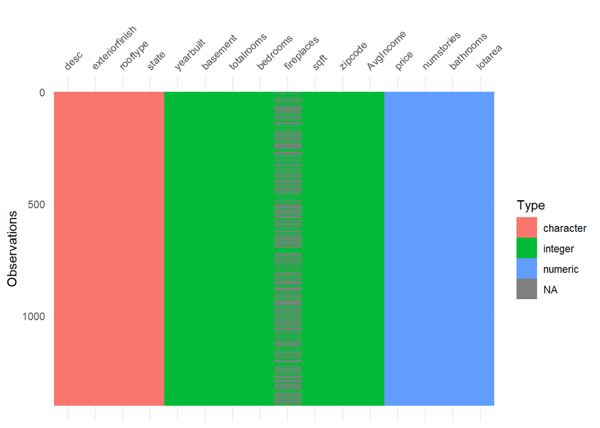

```r
input_train %>% visdat::vis_dat()
```

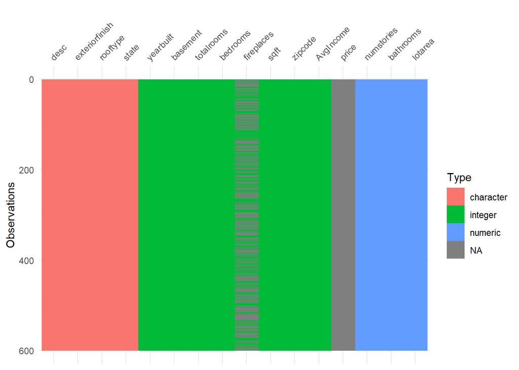

```r
input_test %>% visdat::vis_dat()
```

## Preprocessing

Define preprocessing funciton based on the EDA.

```r
apply_preprocessing <- function(df){

  # delete a column
  df$fireplaces <- NULL
  df$zipcode <- NULL

  # factorize
  df$desc <- as_factor(df$desc)
  df$state <- as_factor(df$state)
  df$rooftype <- as_factor(df$rooftype)
  df$exteriorfinish <- as_factor(df$exteriorfinish)
  df$basement <- as_factor(df$basement)

  df
}
```

Apply preprocessing.

```r
input_train <- apply_preprocessing(input_train)
input_test <- apply_preprocessing(input_test)
```

Check the data types.

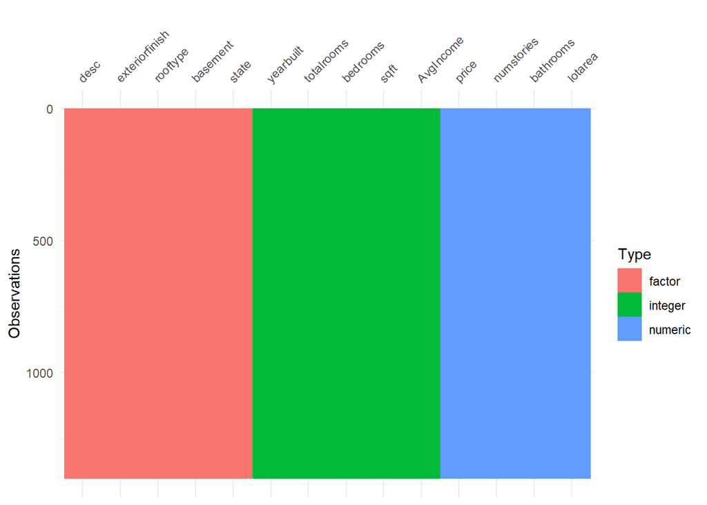

```r
input_train %>% visdat::vis_dat()
```

## Visualizations

Check distributions.

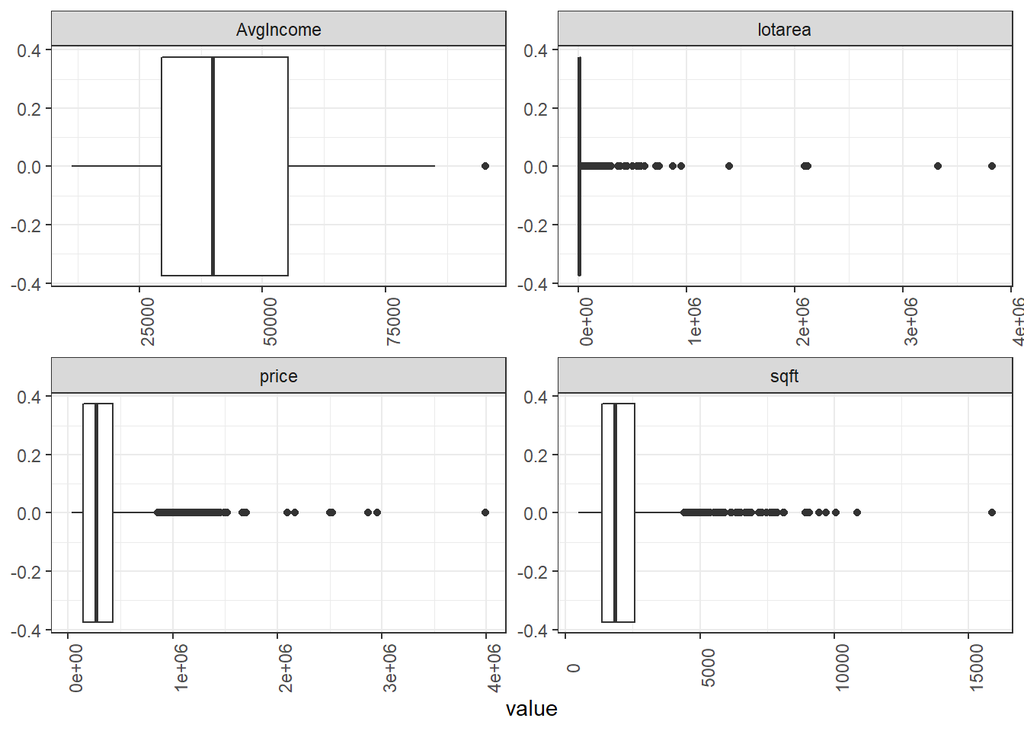

```r
input_train[c('price', 'sqft', 'lotarea', 'AvgIncome')] %>%
  tidyr::gather(key = "key", value = "value") %>%
  ggplot(mapping = aes(x = value)) +
  geom_boxplot() +
  facet_wrap(~key, scales = "free") +
  theme_bw() +
  theme(axis.text.x = element_text(angle = 90))
```

*There are some outliers but I will keep them to keep as much data as possible.*

Counts.

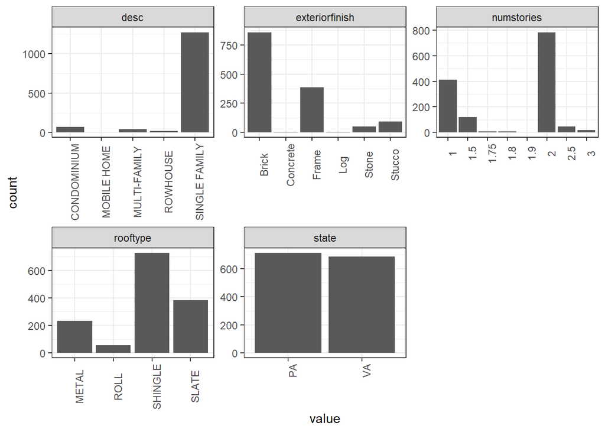

```r
input_train[c('desc', 'exteriorfinish', 'rooftype', 'state', 'numstories')] %>%
  tidyr::gather(key = "key", value = "value") %>%
  ggplot(mapping = aes(x = value)) +
  geom_bar() +
  facet_wrap(~key, scales = "free") +
  theme_bw() +
  theme(axis.text.x = element_text(angle = 90))
```

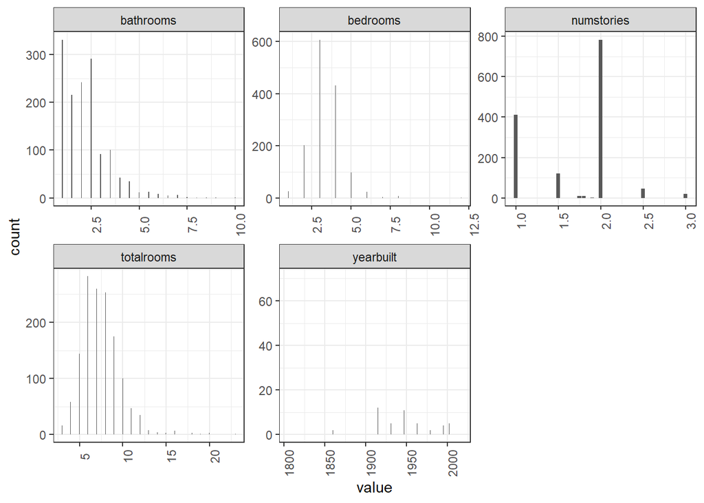

```r
input_train[c('numstories', 'yearbuilt', 'totalrooms', 'bedrooms', 'bathrooms')] %>%
  tidyr::gather(key = "key", value = "value") %>%
  ggplot(mapping = aes(x = value)) +
  geom_bar() +
  facet_wrap(~key, scales = "free") +
  theme_bw() +
  theme(axis.text.x = element_text(angle = 90))
```

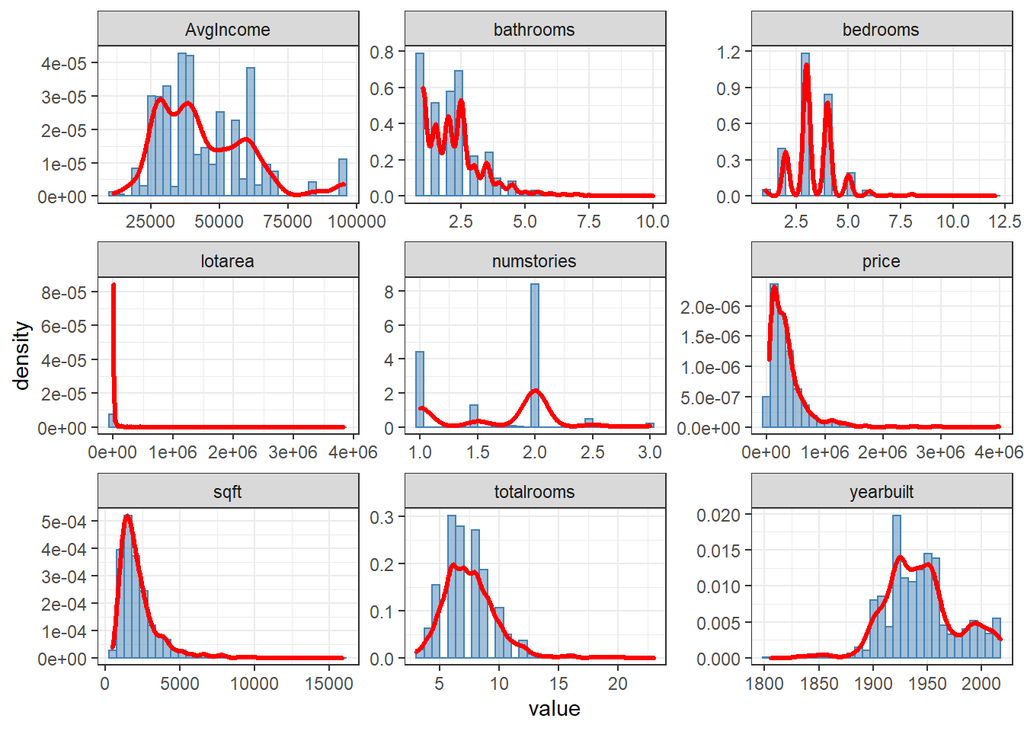

```r
input_train[c('price', 'numstories', 'yearbuilt', 'totalrooms', 'bedrooms', 'bathrooms', 'sqft', 'lotarea', 'AvgIncome')] %>%
  tidyr::gather(key = 'key', value = 'value', ) %>%
  ggplot(mapping = aes(x = value)) +
  geom_histogram(mapping = aes(y = stat(density)),
                 bins = 31,
                 fill = 'steelblue',
                 color = 'steelblue',
                 alpha = 0.5) +
  geom_density(color = 'red',
               size = 1.10) +
  facet_wrap(~key, scales = 'free') +
  theme_bw()
```

Correlation matrix.

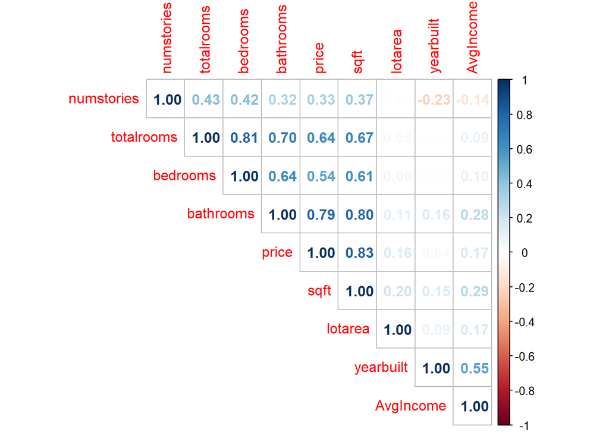

```r
input_train %>%
  select(-c(get_CATEGORICAL_features_list(input_train))) %>%
  as.data.frame() %>%
  cor() %>%
  corrplot::corrplot(method = 'number', type = 'upper', order='hclust')
```

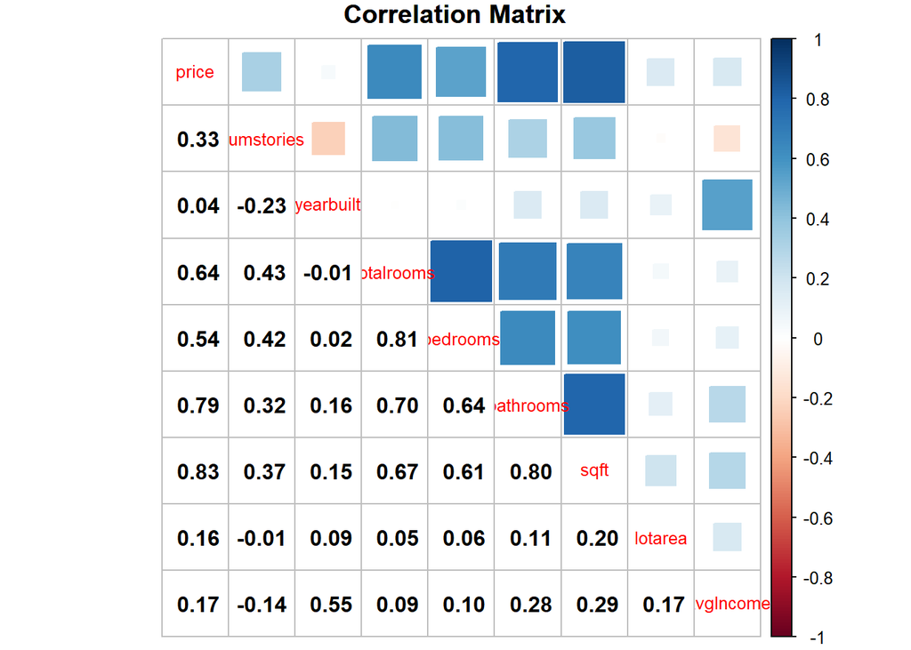

```r
input_train %>%
  select(-c(get_CATEGORICAL_features_list(input_train))) %>%
  as.data.frame() %>%
  cor() %>%
  corrplot::corrplot.mixed(upper='square', lower.col='black', number.cex=1, title='Correlation Matrix', mar=c(0,0,1,0), tl.cex = 0.8)
```

*Some inputs are correlated. Thus, we might need to focus on the models that perform best with correlated inputs or use PCA to uncorrelate them.*

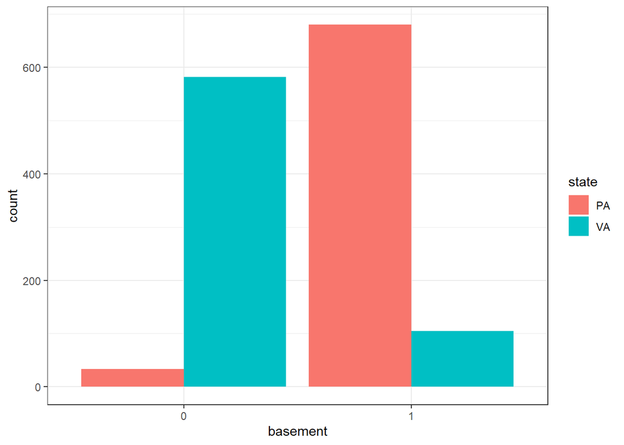

```r
input_train %>%
  ggplot(mapping = aes(x = basement, fill = state)) +
  geom_bar(position = 'dodge') +
  theme_bw()
```

Relationship between Responce and Continious Inputs

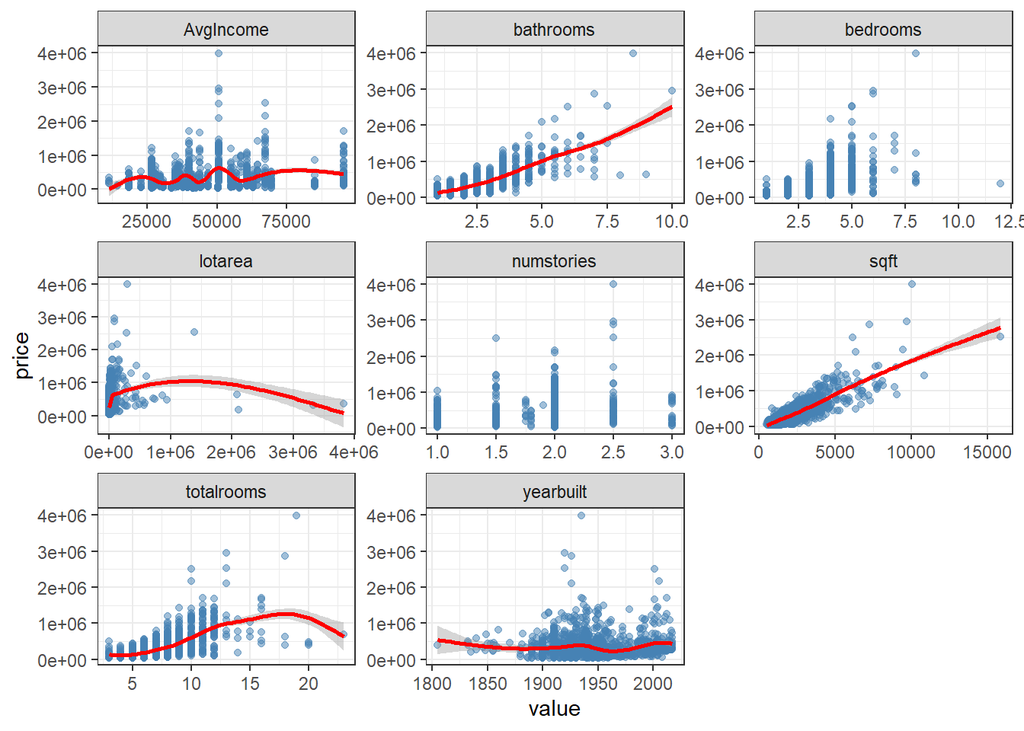

```r
input_train %>%
  select(get_CONTINIOUS_features_list(input_train)) %>%
  tidyr::gather(key = 'key', value = 'value', -price) %>%
  ggplot(mapping = aes(x = value, y = price)) +
  geom_point(fill = 'steelblue',
             color = 'steelblue',
             alpha = 0.5) +
  geom_smooth(color = 'red') +
  facet_wrap(~key, scales = 'free') +
  theme_bw()
```

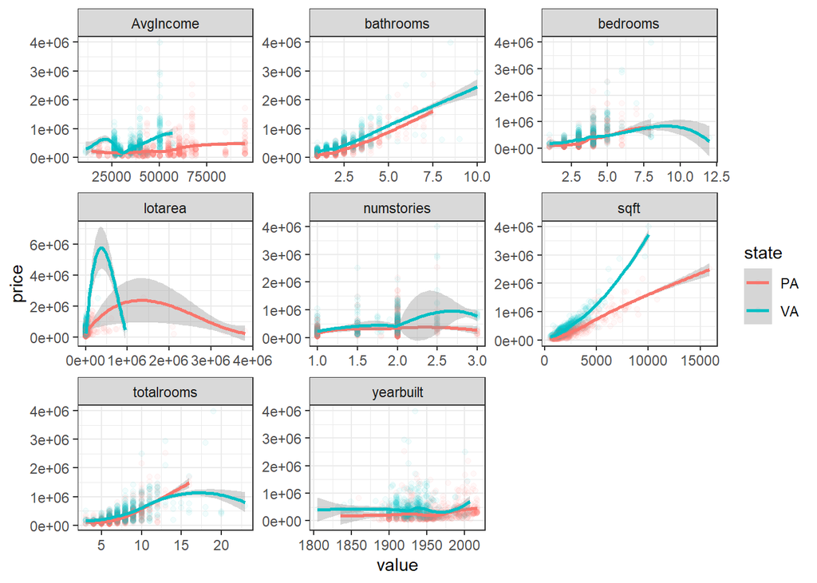

```r
input_train %>%
  tidyr::gather(key = 'key', value = 'value', -price, -c(get_CATEGORICAL_features_list(input_train))) %>%
  ggplot(mapping = aes(x = value, y = price)) +
  geom_point(mapping = aes(color = state),
             alpha = 0.05) +
  geom_smooth(mapping = aes(color = state)) +
  facet_wrap(~key, scales = 'free') +
  theme_bw()
```

# Training Models

## Create `train` and `test` sets out of `input_train`.

Read in the data.

```r
input_train <- read.csv('train.csv', header=T)
```

Preprocess data.

```r
input_train <- apply_preprocessing(input_train)
```

Create stratified samples.

```r
set.seed(1)

cat_vars <- get_CATEGORICAL_features_list(input_train)
cat_vars <- cat_vars[cat_vars != 'id']

sample <- stratified(
  indt=input_train,
  group=cat_vars,
  size=0.8,
  replace=FALSE)

train <- input_train[input_train$id %in% sample$id,]
test <- input_train[!(input_train$id %in% sample$id),]
```

Make `id` column an index.

```r
rownames(input_train) <- input_train$id
input_train$id <- NULL

rownames(train) <- train$id
train$id <- NULL

rownames(test) <- test$id
test$id <- NULL
```

Check the dimensions.

```r
input_train %>%  dim()
```

```
## [1] 1400   14
```

```r
train %>% dim()
```

```
## [1] 1127   14
```

```r
test %>%dim()
```

```
## [1] 273  14
```

Create matrices to use for some of the methods.

```r
train_mat <- model.matrix(price ~ ., data=train)
test_mat <- model.matrix(price ~ ., data=test)

train_mat %>%  dim()
```

```
## [1] 1127   23
```

```r
test_mat %>%  dim()
```

```
## [1] 273  23
```

## Run models

### Baseline

```r
baseline_mse <- mean((test$price - mean(train$price))^2)
baseline_mse
```

```
## [1] 79598514171
```

### Linear Model

```r
set.seed(1)

mod_lm <- lm(price ~ ., data=train)
summary(mod_lm)
```

```
##
## Call:
## lm(formula = price ~ ., data = train)
##
## Residuals:
##     Min      1Q  Median      3Q     Max
## -547812  -65059   -2447   57259 1921956
##
## Coefficients:
##                          Estimate Std. Error t value Pr(>|t|)
## (Intercept)            -1.765e+05  3.406e+05  -0.518 0.604367
## descROWHOUSE            6.160e+04  3.950e+04   1.559 0.119223
## descCONDOMINIUM         3.597e+04  2.133e+04   1.686 0.092014 .
## descMULTI-FAMILY       -8.747e+04  2.648e+04  -3.303 0.000987 ***
## descMOBILE HOME        -6.456e+04  1.645e+05  -0.392 0.694849
## numstories             -1.702e+04  1.059e+04  -1.608 0.108223
## yearbuilt              -4.853e+01  1.760e+02  -0.276 0.782790
## exteriorfinishFrame    -1.140e+04  1.040e+04  -1.096 0.273366
## exteriorfinishStucco   -9.119e+04  1.737e+04  -5.249 1.83e-07 ***
## exteriorfinishStone    -4.671e+04  2.391e+04  -1.953 0.051045 .
## exteriorfinishConcrete  4.469e+04  7.070e+04   0.632 0.527443
## exteriorfinishLog      -3.555e+04  8.221e+04  -0.432 0.665552
## rooftypeSLATE           1.004e+05  1.373e+04   7.308 5.19e-13 ***
## rooftypeMETAL           5.005e+04  1.705e+04   2.935 0.003403 **
## rooftypeROLL            6.421e+04  2.277e+04   2.820 0.004887 **
## basement1               4.267e+04  1.545e+04   2.761 0.005856 **
## totalrooms              3.302e+00  3.706e+03   0.001 0.999289
## bedrooms               -1.500e+04  7.084e+03  -2.117 0.034459 *
## bathrooms               7.162e+04  6.575e+03  10.893  < 2e-16 ***
## sqft                    1.509e+02  5.597e+00  26.968  < 2e-16 ***
## lotarea                 5.830e-02  2.654e-02   2.197 0.028232 *
## stateVA                 1.971e+05  1.844e+04  10.691  < 2e-16 ***
## AvgIncome               1.173e+00  3.542e-01   3.313 0.000954 ***
## ---
## Signif. codes:  0 '***' 0.001 '**' 0.01 '*' 0.05 '.' 0.1 ' ' 1
##
## Residual standard error: 139100 on 1104 degrees of freedom
## Multiple R-squared:  0.825,  Adjusted R-squared:  0.8215
## F-statistic: 236.5 on 22 and 1104 DF,  p-value: < 2.2e-16
```

```r
pred_lm <- predict(mod_lm, test)
lm_mse <- mean((test$price - pred_lm)^2)
lm_mse
```

```
## [1] 10745202369
```

### Best Subset Selection Selection

```r
n_size <- 22
regfit_full <- regsubsets(price~., data=train, nvmax=n_size)
regfit_full_sum <- regfit_full %>% summary()
regfit_full_sum
```

```
## Subset selection object
## Call: regsubsets.formula(price ~ ., data = train, nvmax = n_size)
## 22 Variables  (and intercept)
##                        Forced in Forced out
## descROWHOUSE               FALSE      FALSE
## descCONDOMINIUM            FALSE      FALSE
## descMULTI-FAMILY           FALSE      FALSE
## descMOBILE HOME            FALSE      FALSE
## numstories                 FALSE      FALSE
## yearbuilt                  FALSE      FALSE
## exteriorfinishFrame        FALSE      FALSE
## exteriorfinishStucco       FALSE      FALSE
## exteriorfinishStone        FALSE      FALSE
## exteriorfinishConcrete     FALSE      FALSE
## exteriorfinishLog          FALSE      FALSE
```

[output cut: 128 more lines]

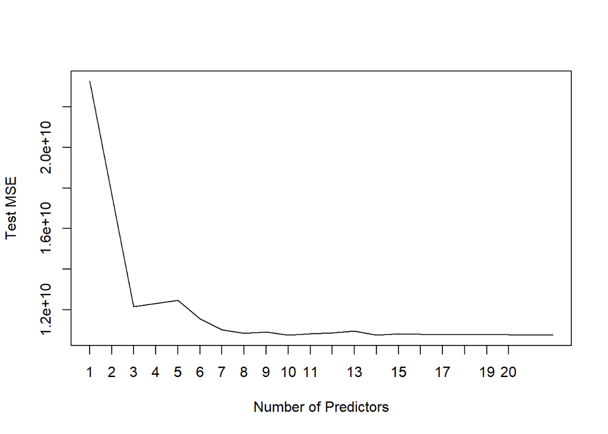

```r
errs_test <- rep(NA, n_size)

for (i in 1:n_size) {
  cur_coef <- coef(regfit_full, id=i)
  pred <- test_mat[, names(cur_coef)] %*% cur_coef
  errs_test[i] <- mean((test$price - pred)^2)
}

plot(errs_test, type='l',xlab='Number of Predictors',ylab="Test MSE")
axis(side=1,at=1:20)
```

### Forward Stepwise Selection

```r
regfit_fwd <- regsubsets(price~., data=train,
                         nvmax=n_size,
                         method='forward')

regfit_fwd_sum <- regfit_fwd %>% summary()
regfit_fwd_sum
```

```
## Subset selection object
## Call: regsubsets.formula(price ~ ., data = train, nvmax = n_size, method = "forward")
## 22 Variables  (and intercept)
##                        Forced in Forced out
## descROWHOUSE               FALSE      FALSE
## descCONDOMINIUM            FALSE      FALSE
## descMULTI-FAMILY           FALSE      FALSE
## descMOBILE HOME            FALSE      FALSE
## numstories                 FALSE      FALSE
## yearbuilt                  FALSE      FALSE
## exteriorfinishFrame        FALSE      FALSE
## exteriorfinishStucco       FALSE      FALSE
## exteriorfinishStone        FALSE      FALSE
## exteriorfinishConcrete     FALSE      FALSE
## exteriorfinishLog          FALSE      FALSE
```

[output cut: 128 more lines]

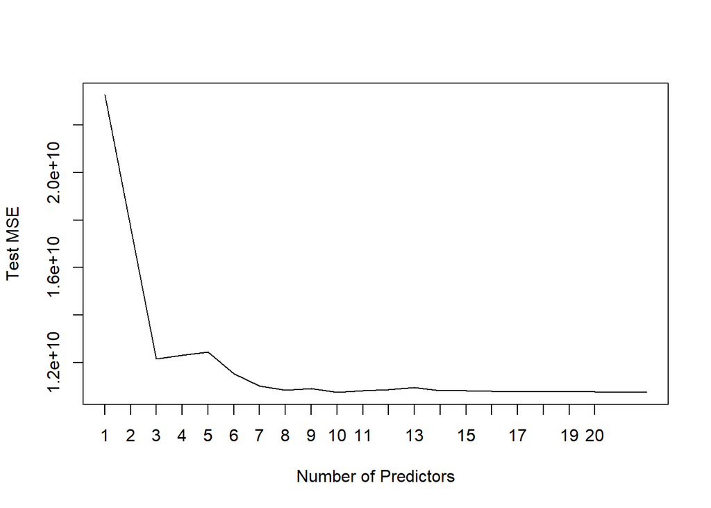

```r
errs_test <- rep(NA, n_size)

for (i in 1:n_size) {
  cur_coef <- coef(regfit_fwd, id=i)
  pred <- test_mat[, names(cur_coef)] %*% cur_coef
  errs_test[i] <- mean((test$price - pred)^2)
}

plot(errs_test, type='l',xlab='Number of Predictors',ylab="Test MSE")
axis(side=1,at=1:20)
```

### Backward Stepwise Selection

```r
regfit_bwd <- regsubsets(price~., data=train,
                         nvmax=n_size,
                         method='backward')

regfit_bwd_sum <- regfit_bwd %>% summary()
regfit_bwd_sum
```

```
## Subset selection object
## Call: regsubsets.formula(price ~ ., data = train, nvmax = n_size, method = "backward")
## 22 Variables  (and intercept)
##                        Forced in Forced out
## descROWHOUSE               FALSE      FALSE
## descCONDOMINIUM            FALSE      FALSE
## descMULTI-FAMILY           FALSE      FALSE
## descMOBILE HOME            FALSE      FALSE
## numstories                 FALSE      FALSE
## yearbuilt                  FALSE      FALSE
## exteriorfinishFrame        FALSE      FALSE
## exteriorfinishStucco       FALSE      FALSE
## exteriorfinishStone        FALSE      FALSE
## exteriorfinishConcrete     FALSE      FALSE
## exteriorfinishLog          FALSE      FALSE
```

[output cut: 128 more lines]

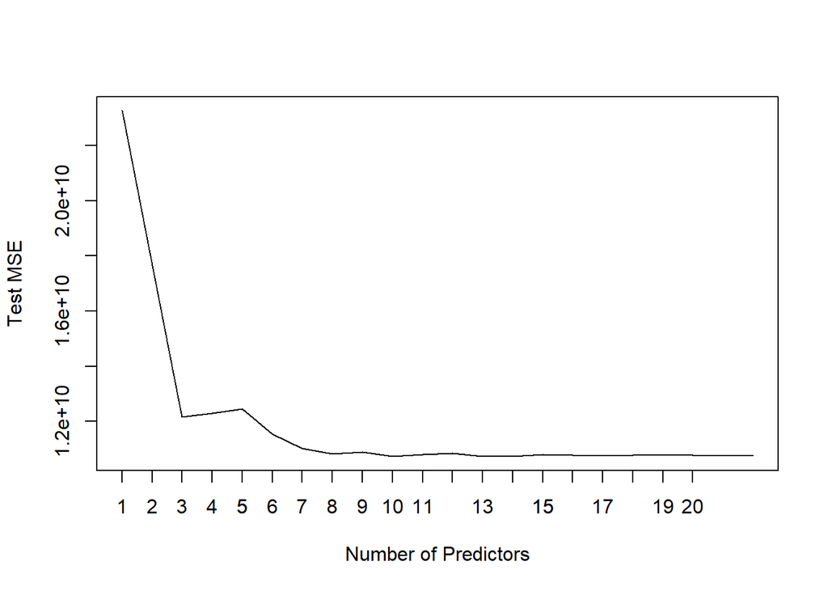

```r
errs_test <- rep(NA, n_size)

for (i in 1:n_size) {
  cur_coef <- coef(regfit_bwd, id=i)
  pred <- test_mat[, names(cur_coef)] %*% cur_coef
  errs_test[i] <- mean((test$price - pred)^2)
}

plot(errs_test, type='l',xlab='Number of Predictors',ylab="Test MSE")
axis(side=1,at=1:20)
```

Based on the graphs, I would choose either`3` or `7` variables. Interestingly enough, all the subset selections methods identified the same set of variables for `3` and `7`.

### Linear Model - 3 Vars

```r
set.seed(1)

mod_lm_3 <- lm(price ~ sqft + state + bathrooms, data=train)
summary(mod_lm_3)
```

```
##
## Call:
## lm(formula = price ~ sqft + state + bathrooms, data = train)
##
## Residuals:
##     Min      1Q  Median      3Q     Max
## -663325  -73410    5074   69073 1909729
##
## Coefficients:
##               Estimate Std. Error t value Pr(>|t|)
## (Intercept) -242166.58   10391.03  -23.30   <2e-16 ***
## sqft            148.22       5.29   28.02   <2e-16 ***
## stateVA      178684.78    8953.47   19.96   <2e-16 ***
## bathrooms     76867.60    6121.59   12.56   <2e-16 ***
## ---
## Signif. codes:  0 '***' 0.001 '**' 0.01 '*' 0.05 '.' 0.1 ' ' 1
##
## Residual standard error: 148100 on 1123 degrees of freedom
## Multiple R-squared:  0.7982, Adjusted R-squared:  0.7977
## F-statistic:  1481 on 3 and 1123 DF,  p-value: < 2.2e-16
```

```r
pred_lm_3 <- predict(mod_lm_3, test)
lm_3_mse <- mean((test$price - pred_lm_3)^2)
lm_3_mse
```

```
## [1] 12154330974
```

### Linear Model - 7 Vars

```r
set.seed(1)

mod_lm_7 <- lm(price ~ sqft + state + bathrooms + desc + exteriorfinish + rooftype + bedrooms, data=train)
summary(mod_lm_7)
```

```
##
## Call:
## lm(formula = price ~ sqft + state + bathrooms + desc + exteriorfinish +
##     rooftype + bedrooms, data = train)
##
## Residuals:
##     Min      1Q  Median      3Q     Max
## -585284  -65568    1087   58181 1910960
##
## Coefficients:
##                          Estimate Std. Error t value Pr(>|t|)
## (Intercept)            -1.905e+05  1.706e+04 -11.170  < 2e-16 ***
## sqft                    1.512e+02  5.276e+00  28.667  < 2e-16 ***
## stateVA                 1.437e+05  1.239e+04  11.606  < 2e-16 ***
## bathrooms               7.774e+04  6.236e+03  12.465  < 2e-16 ***
## descROWHOUSE            2.707e+04  3.867e+04   0.700 0.484046
## descCONDOMINIUM         1.379e+04  2.060e+04   0.669 0.503544
## descMULTI-FAMILY       -1.088e+05  2.543e+04  -4.277 2.06e-05 ***
## descMOBILE HOME         1.523e+05  1.410e+05   1.080 0.280268
## exteriorfinishFrame    -1.159e+04  1.034e+04  -1.121 0.262425
## exteriorfinishStucco   -9.790e+04  1.740e+04  -5.628 2.31e-08 ***
## exteriorfinishStone    -4.450e+04  2.388e+04  -1.863 0.062699 .
## exteriorfinishConcrete  3.969e+04  7.127e+04   0.557 0.577712
## exteriorfinishLog       1.200e+04  8.224e+04   0.146 0.883965
## rooftypeSLATE           9.787e+04  1.311e+04   7.466 1.67e-13 ***
## rooftypeMETAL           3.748e+04  1.536e+04   2.440 0.014841 *
## rooftypeROLL            4.685e+04  2.270e+04   2.064 0.039279 *
## bedrooms               -1.921e+04  5.819e+03  -3.301 0.000993 ***
## ---
## Signif. codes:  0 '***' 0.001 '**' 0.01 '*' 0.05 '.' 0.1 ' ' 1
##
## Residual standard error: 140700 on 1110 degrees of freedom
## Multiple R-squared:  0.8199, Adjusted R-squared:  0.8173
## F-statistic: 315.9 on 16 and 1110 DF,  p-value: < 2.2e-16
```

```r
pred_lm_7 <- predict(mod_lm_7, test)
lm_7_mse <- mean((test$price - pred_lm_7)^2)
lm_7_mse
```

```
## [1] 10933707494
```

### Ridge

```r
set.seed(1)

mod_ridge_cv <- cv.glmnet(train_mat, train[, 'price'], alpha=0, type.measure='mse', nfolds=5)

best_lambda <- mod_ridge_cv$lambda.min
pred_ridge <- predict(mod_ridge_cv, s=best_lambda, newx=test_mat)
ridge_mse <- mean((test$price - pred_ridge)^2)
ridge_mse
```

```
## [1] 10978949422
```

### Lasso

```r
set.seed(1)
mod_lasso_cv <- cv.glmnet(train_mat, train[, 'price'], alpha=1, type.measure='mse', nfolds=5)

best_lambda <- mod_lasso_cv$lambda.min
pred_lasso <- predict(mod_lasso_cv, s=best_lambda, newx=test_mat)
lasso_mse <- mean((test$price - pred_lasso)^2)
lasso_mse
```

```
## [1] 10697254072
```

```r
# non-zero coefficients
sum(predict(mod_lasso_cv, s=best_lambda, newx=test_mat, type='coefficients') != 0)
```

```
## [1] 19
```

### PCR

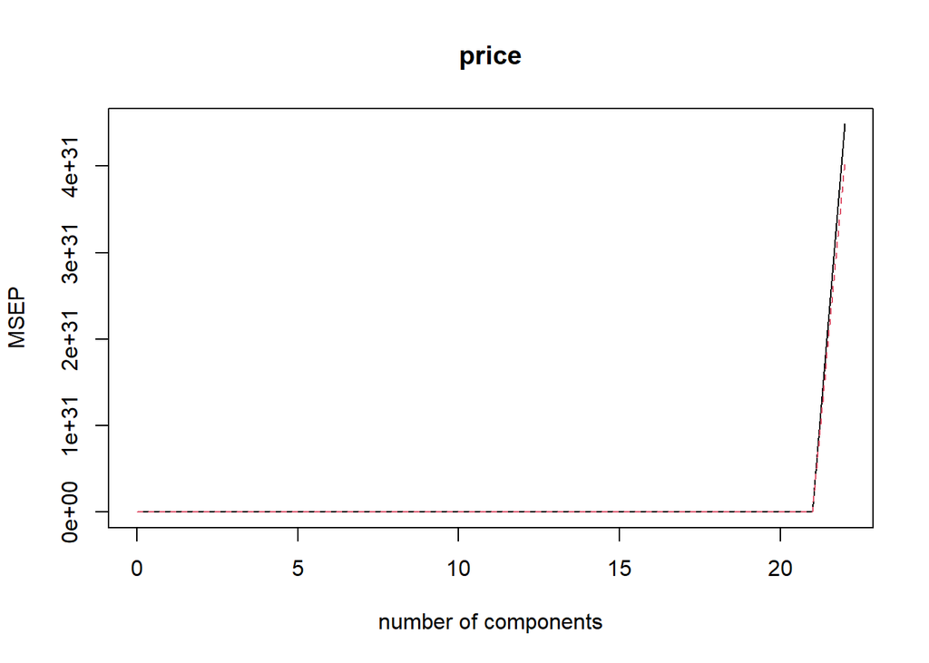

```r
set.seed(1)

mod_pcr <- pcr(price ~ ., data=train, scale=F, validation='CV')
validationplot(mod_pcr, val.type='MSEP')
```

```r
set.seed(1)

pred_pcr <- predict(mod_pcr, test, ncomp=20)
pcr_mse <- mean((test$price - pred_pcr)^2)
pcr_mse
```

```
## [1] 10742195148
```

### PLS

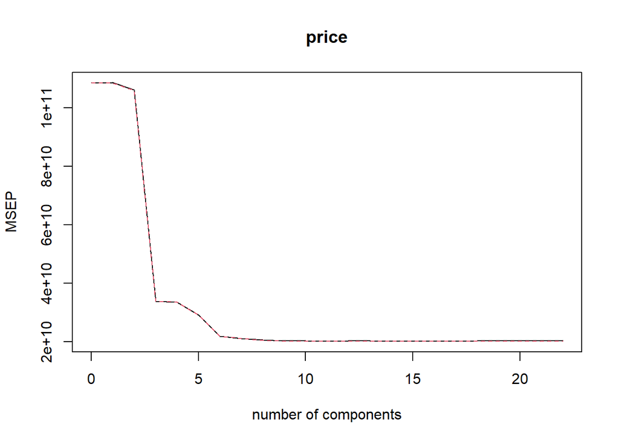

```r
set.seed(1)

mod_pls <- plsr(price ~ ., data=train, scale=F, validation='CV')
validationplot(mod_pls, val.type='MSEP')
```

```r
set.seed(1)

pred_pls <- predict(mod_pls, test, ncomp=6)
pls_mse <- mean((test$price - pred_pls)^2)
pls_mse
```

```
## [1] 10689650924
```

### Polynomials

```r
set.seed(1)

degree <- 10
cv_error <- rep(NA,degree)

for (i in 1:degree){
  glm_fit <- glm(price ~ poly(sqft,i) + poly(bathrooms,i) ,data=input_train)
  cv_error[i]<- cv.glm(input_train, glm_fit, K=10)$delta[1]
}

which.min(cv_error)
```

```
## [1] 2
```

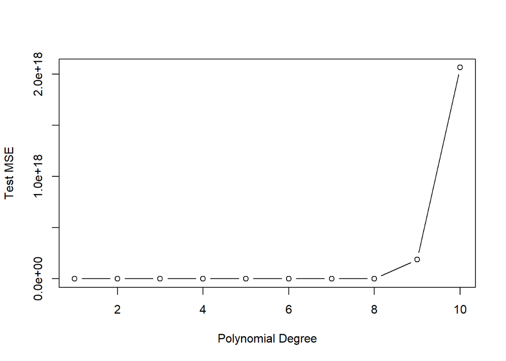

```r
plot(cv_error, type='b', xlab='Polynomial Degree', ylab='Test MSE')
```

```r
mod_poly <- glm(price ~ poly(sqft,which.min(cv_error)) + poly(bathrooms,which.min(cv_error)) ,data=train)

pred_poly <- predict(mod_poly, test)
poly_mse <- mean((test$price - pred_poly)^2)
poly_mse
```

```
## [1] 17164105421
```

### Splines

```r
set.seed(1)

df <- 10
cv_error <- rep(NA,df)

for (i in 2:df){
  spline_fit <- glm(price ~ ns(sqft, df=i), data=input_train)
  cv_error[i]<- cv.glm(input_train, spline_fit, K=10)$delta[1]
}

which.min(cv_error)
```

```
## [1] 2
```

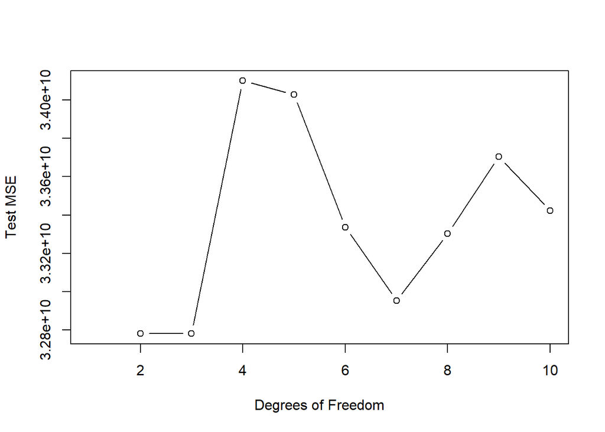

```r
plot(cv_error, type='b', xlab='Degrees of Freedom', ylab='Test MSE')
```

```r
mod_spline <- glm(price ~ ns(sqft, df=which.min(cv_error)), data=input_train)

pred_spline <- predict(mod_spline, test)
spline_mse <- mean((test$price - pred_spline)^2)
spline_mse
```

```
## [1] 23214703112
```

### Trees

Create data sets.

```r
train_trees <- createDummyFeatures(train, cols=cat_vars)
test_trees <- createDummyFeatures(test, cols=cat_vars)
```

```r
mod_tree <- tree(price ~ ., data=train_trees)
summary(mod_tree)
```

```
##
## Regression tree:
## tree(formula = price ~ ., data = train_trees)
## Variables actually used in tree construction:
## [1] "sqft"             "bathrooms"        "rooftype.SHINGLE" "state.PA"
## [5] "lotarea"
## Number of terminal nodes:  11
## Residual mean deviance:  1.934e+10 = 2.159e+13 / 1116
## Distribution of residuals:
##     Min.  1st Qu.   Median     Mean  3rd Qu.     Max.
## -1184000   -66350    -9055        0    66200  1378000
```

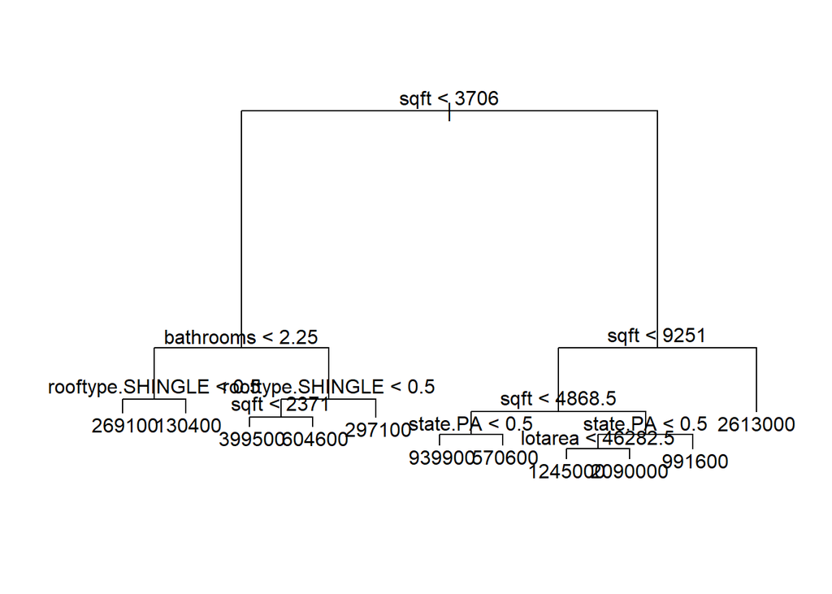

```r
plot(mod_tree)
text(mod_tree, pretty=0)
```

```r
set.seed(1)

pred_tree <- predict(mod_tree, test_trees)
tree_mse <- mean((test_trees$price - pred_tree)^2)
tree_mse
```

```
## [1] 21359816377
```

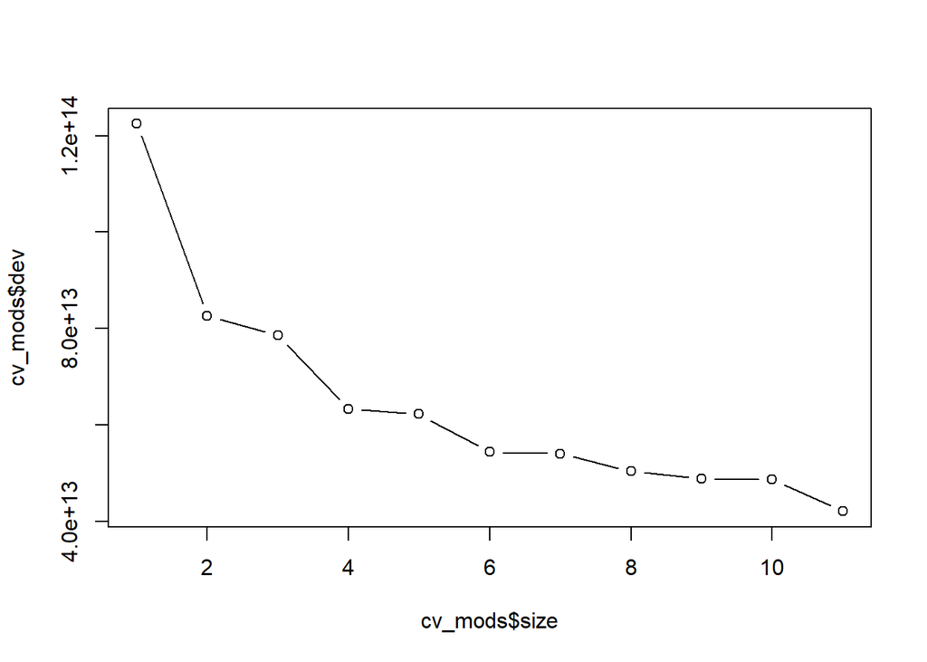

```r
set.seed(1)

cv_mods <- cv.tree(mod_tree)
plot(cv_mods$size, cv_mods$dev, type='b')
```

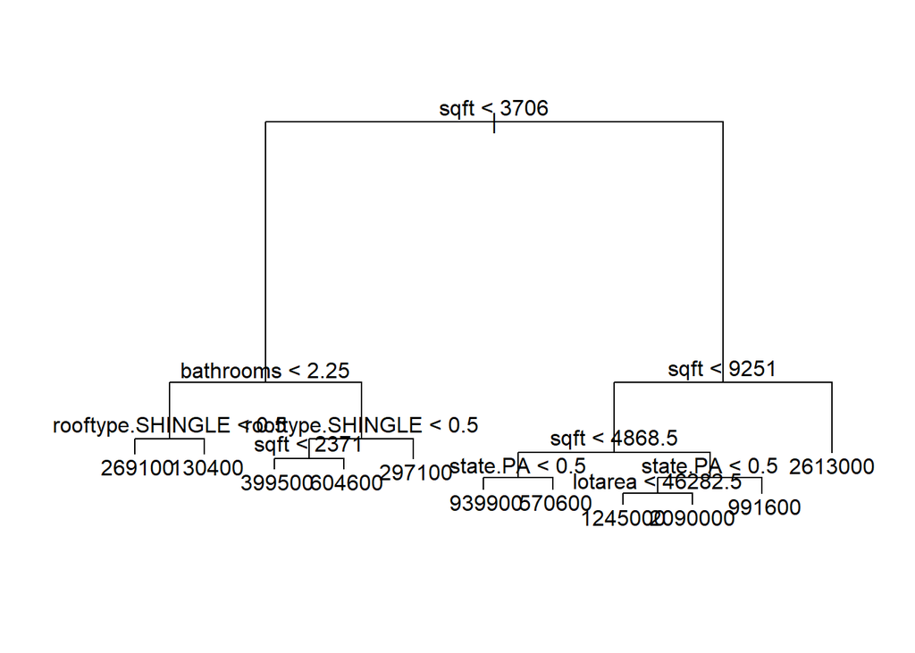

```r
set.seed(1)

pruned_tree <- prune.tree(mod_tree, best=11)
plot(pruned_tree)
text(pruned_tree, pretty=0)
```

```r
set.seed(1)

pred_pruned <- predict(pruned_tree, test_trees)
pruned_mse <- mean((test_trees$price - pred_pruned)^2)
pruned_mse
```

```
## [1] 21359816377
```

### Bagged tree

```r
set.seed(1)

num_par <- ncol(train_trees)-1

mod_bagged_tree <- randomForest(price ~ ., data=train_trees, mtry=num_par, ntree=1000, importance=T)
bagged_pred <- predict(mod_bagged_tree, test_trees)
bagged_mse <- mean((test_trees$price - bagged_pred)^2)
bagged_mse
```

```
## [1] 10532220607
```

```r
importance(mod_bagged_tree)
```

```
##                            %IncMSE IncNodePurity
## numstories               6.2276409  7.430950e+11
## yearbuilt               17.8244017  1.581237e+12
## totalrooms               2.3041957  3.335461e+12
## bedrooms                -1.8175918  6.022018e+11
## bathrooms               21.1554211  1.624483e+13
## sqft                    84.9281686  7.823375e+13
## lotarea                 20.5252102  3.566015e+12
## AvgIncome               39.8045811  1.814363e+12
## desc.SINGLE.FAMILY      11.3223289  7.106044e+10
## desc.ROWHOUSE           -2.6920713  2.439628e+09
## desc.CONDOMINIUM         7.8709582  1.830979e+10
## desc.MULTI.FAMILY        1.2414736  6.801353e+10
## desc.MOBILE.HOME         0.0000000  2.326513e+08
## exteriorfinish.Brick    31.5674476  5.168254e+11
## exteriorfinish.Frame     5.0587800  2.102864e+11
## exteriorfinish.Stucco   -1.7211524  1.074997e+11
## exteriorfinish.Stone     0.2699726  6.079355e+10
## exteriorfinish.Concrete  1.1460925  1.979686e+09
## exteriorfinish.Log       1.0005004  5.737366e+08
## rooftype.SHINGLE        68.4834317  6.494296e+12
## rooftype.SLATE          14.8530325  1.166078e+12
## rooftype.METAL           9.1711085  1.553049e+11
## rooftype.ROLL           10.6064602  7.044753e+10
## basement.0               6.4401498  2.007322e+11
## basement.1               2.8238752  1.742478e+11
## state.PA                32.5894056  2.486586e+12
## state.VA                30.9543804  2.651106e+12
```

### Random Forest

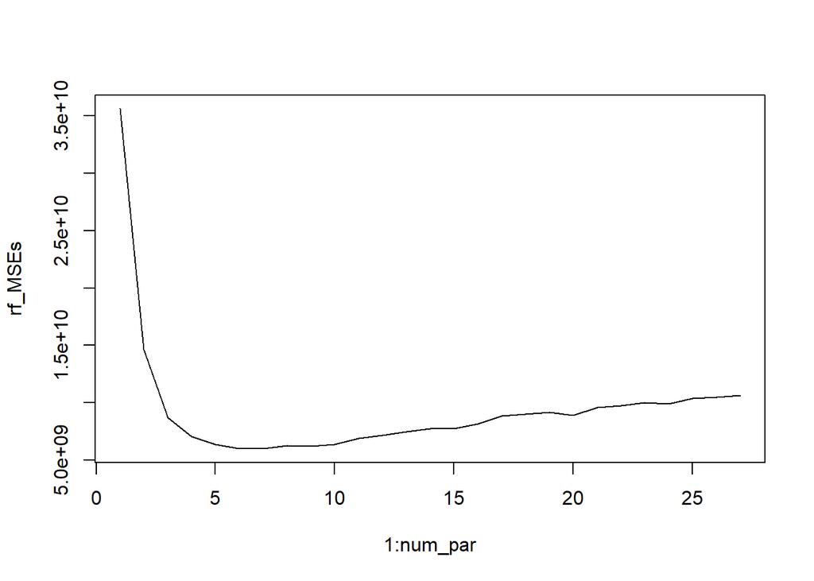

```r
num_par <- ncol(train_trees)-1
rf_MSEs <- c()

for(i in 1:num_par){
  set.seed(i)
  mod_rf <- randomForest(price ~ ., data=train_trees, mtry=i, ntree=1000, importance=T)
  rf_pred <- predict(mod_rf, test_trees)
  rf_MSEs <- rbind(rf_MSEs, mean((test_trees$price - rf_pred)^2))
}

plot(1:num_par, rf_MSEs, type='l')
```

```r
which.min(rf_MSEs)
```

```
## [1] 7
```

```r
set.seed(1)

mod_rf <- randomForest(price ~ ., data=train_trees, mtry=which.min(rf_MSEs), ntree=1000, importance=T)
rf_pred <- predict(mod_rf, test_trees)
rf_mse <- mean((test_trees$price - rf_pred)^2)
rf_mse
```

```
## [1] 6047291110
```

```r
importance(mod_rf)
```

```
##                            %IncMSE IncNodePurity
## numstories              10.5040684  2.388108e+12
## yearbuilt               16.7230772  2.778015e+12
## totalrooms              13.7854806  1.239890e+13
## bedrooms                 6.9511822  6.262844e+12
## bathrooms               32.4533239  2.729135e+13
## sqft                    45.8283556  3.818590e+13
## lotarea                 18.2743974  9.640821e+12
## AvgIncome               23.5068912  3.769533e+12
## desc.SINGLE.FAMILY       6.5887967  1.817595e+11
## desc.ROWHOUSE            1.3882223  7.049255e+09
## desc.CONDOMINIUM         9.5183958  3.976535e+10
## desc.MULTI.FAMILY        4.1001183  1.911167e+11
## desc.MOBILE.HOME         0.0000000  3.101048e+09
## exteriorfinish.Brick    16.7170507  6.475678e+11
## exteriorfinish.Frame     8.6830002  4.852858e+11
## exteriorfinish.Stucco    8.6712094  2.615453e+11
## exteriorfinish.Stone    -1.4684606  2.798655e+11
## exteriorfinish.Concrete -0.9872811  8.488917e+09
## exteriorfinish.Log      -2.1637043  9.384247e+09
## rooftype.SHINGLE        25.7783352  4.184140e+12
## rooftype.SLATE          19.3400252  3.204900e+12
## rooftype.METAL          13.2763730  5.430393e+11
## rooftype.ROLL            4.9347066  1.385325e+11
## basement.0               7.1226508  6.620527e+11
## basement.1               8.5264028  7.387747e+11
## state.PA                22.0276188  2.254889e+12
## state.VA                24.6762017  2.194328e+12
```

### Boosting

```r
lambdas <- seq(0.01, 0.1, by=0.005)
int_depth <- seq(1, 5, by=1)
length_lambdas <- length(lambdas)
length_depth <- length(int_depth)
counter <- 1
err_test <- rep(NA, (length_lambdas*length_depth))

for (i in 1:length_lambdas) {
  for (j in 1:length_depth) {
    set.seed(counter)
    mod_boost <- gbm(price~., data=train_trees, distribution='gaussian', n.trees=1000, shrinkage=lambdas[i], interaction.depth=int_depth[j])
    pred_test <- predict(mod_boost, test_trees, n.trees=1000)
    err_test[counter] <- mean((test_trees$price - pred_test)^2)
    counter <- counter+1
  }
}
```

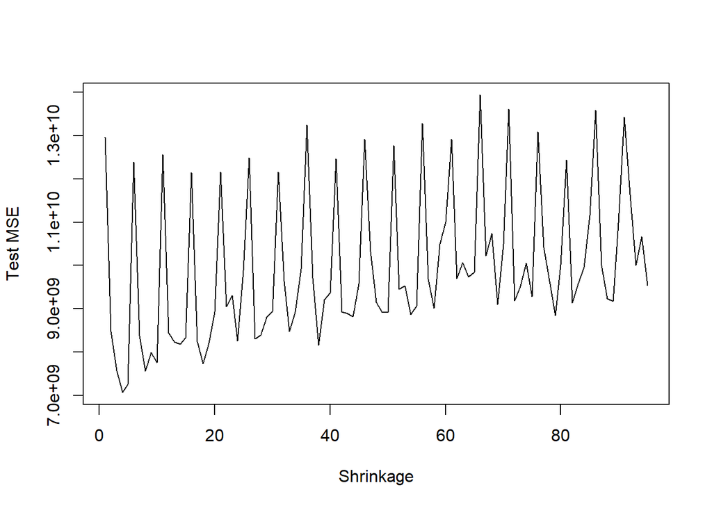

```r
plot(err_test, type='l', xlab='Shrinkage', ylab='Test MSE')
```

```r
which.min(err_test)
```

```
## [1] 4
```

```r
set.seed(1)

mod_boost <- gbm(price~., data=train_trees, distribution='gaussian', n.trees=1000, shrinkage=0.01, interaction.depth=4)
pred_test <- predict(mod_boost, test_trees, n.trees=1000)
boost_mse <- mean((test_trees$price - pred_test)^2)
boost_mse
```

```
## [1] 7180889097
```

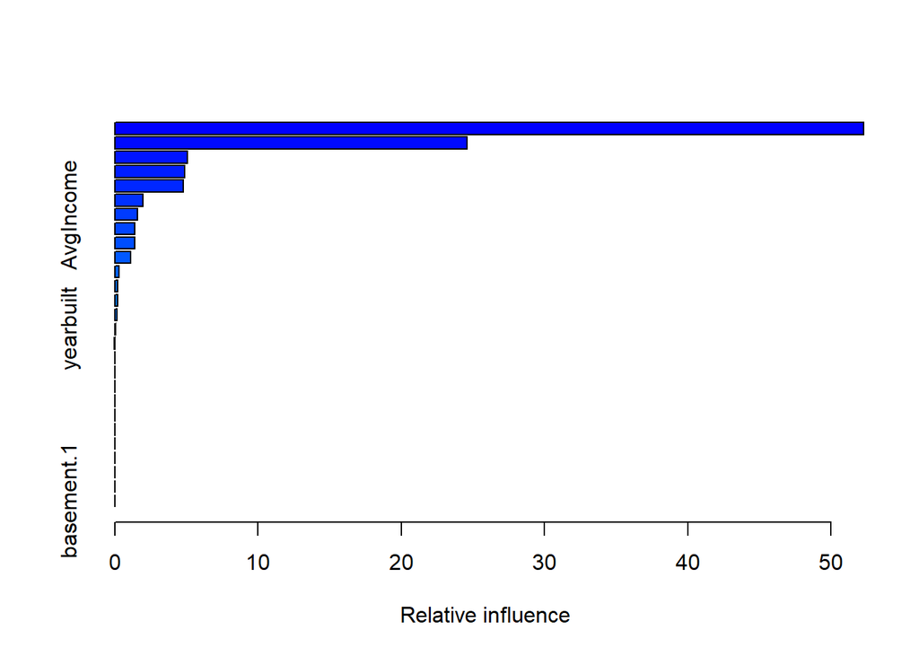

```
##                                             var     rel.inf
## sqft                                       sqft 52.26549018
## bathrooms                             bathrooms 24.57631353
## totalrooms                           totalrooms  5.08874765
## lotarea                                 lotarea  4.89389279
## rooftype.SHINGLE               rooftype.SHINGLE  4.76527351
## state.PA                               state.PA  1.98560317
## AvgIncome                             AvgIncome  1.55686274
## rooftype.SLATE                   rooftype.SLATE  1.40426956
## state.VA                               state.VA  1.40422129
## bedrooms                               bedrooms  1.08927055
## numstories                           numstories  0.30084912
## exteriorfinish.Stucco     exteriorfinish.Stucco  0.21921194
## desc.MULTI.FAMILY             desc.MULTI.FAMILY  0.20077339
## exteriorfinish.Brick       exteriorfinish.Brick  0.15325522
## yearbuilt                             yearbuilt  0.06720820
## exteriorfinish.Stone       exteriorfinish.Stone  0.02875714
## desc.SINGLE.FAMILY           desc.SINGLE.FAMILY  0.00000000
## desc.ROWHOUSE                     desc.ROWHOUSE  0.00000000
## desc.CONDOMINIUM               desc.CONDOMINIUM  0.00000000
## desc.MOBILE.HOME               desc.MOBILE.HOME  0.00000000
## exteriorfinish.Frame       exteriorfinish.Frame  0.00000000
## exteriorfinish.Concrete exteriorfinish.Concrete  0.00000000
## exteriorfinish.Log           exteriorfinish.Log  0.00000000
## rooftype.METAL                   rooftype.METAL  0.00000000
## rooftype.ROLL                     rooftype.ROLL  0.00000000
## basement.0                           basement.0  0.00000000
## basement.1                           basement.1  0.00000000
```

```r
mod_boost <- gbm(price~., data=train_trees, distribution='gaussian', n.trees=1000, shrinkage=lambdas[5])
summary(mod_boost)
```

### KNN

```r
set.seed(1)

my_ctrl <- trainControl(method='cv', number=5)
k_grid <- expand.grid(k=seq(1, 25, by=2))

#fit_knn <- train(price ~ ., data=input_train,
#                 method = 'knn',
#                 metric = 'RMSE',
#                 tuneGrid = k_grid,
#                 trControl = my_ctrl)

#ggplot(fit_knn) + theme_bw()
```

```r
mod_knn <- knn.reg(train_mat, test = test_mat, train$price, k=5)
knn_pred <- mod_knn$pred
knn_mse <- mean((test$price - knn_pred)^2)
knn_mse
```

```
## [1] 36251762340
```

## Compare MSEs

```r
MSEs <- c(baseline_mse=baseline_mse,
          lm_mse=lm_mse,
          lm_3_mse=lm_3_mse,
          lm_7_mse=lm_7_mse,
          ridge_mse=ridge_mse,
          lasso_mse=lasso_mse,
          knn_mse=knn_mse,
          pcr_mse=pcr_mse,
          pls_mse=pls_mse,
          poly_mse=poly_mse,
          spline_mse=spline_mse,
          tree_mse=tree_mse,
          bagged_mse=bagged_mse,
          rf_mse=rf_mse,
          boost_mse=boost_mse)
MSEs
```

```
## baseline_mse       lm_mse     lm_3_mse     lm_7_mse    ridge_mse    lasso_mse
##  79598514171  10745202369  12154330974  10933707494  10978949422  10697254072
##      knn_mse      pcr_mse      pls_mse     poly_mse   spline_mse     tree_mse
##  36251762340  10742195148  10689650924  17164105421  23214703112  21359816377
##   bagged_mse       rf_mse    boost_mse
##  10532220607   6047291110   7180889097
```

```r
comp <- data.frame(method=c('Baseline', 'LM', 'LM with 3', 'LM with 7', 'Ridge',
                            'Lasso', 'PCR', 'PLS', 'Poly',
                            'Spline', 'Tree', 'Bagged', 'RF',
                            'Boosted', 'KNN'),
        test_MSE=c(baseline_mse, lm_mse, lm_3_mse, lm_7_mse,
                   ridge_mse, lasso_mse, pcr_mse,
                   pls_mse, poly_mse, spline_mse,
                   tree_mse,bagged_mse, rf_mse,
                   boost_mse,knn_mse))

comp[order(comp$test_MSE), ]
```

```
##       method    test_MSE
## 13        RF  6047291110
## 14   Boosted  7180889097
## 12    Bagged 10532220607
## 8        PLS 10689650924
## 6      Lasso 10697254072
## 7        PCR 10742195148
## 2         LM 10745202369
## 4  LM with 7 10933707494
## 5      Ridge 10978949422
## 3  LM with 3 12154330974
## 9       Poly 17164105421
## 11      Tree 21359816377
## 10    Spline 23214703112
## 15       KNN 36251762340
## 1   Baseline 79598514171
```

Choose the best model.

```r
input_test <- read.csv('test.csv', header=T, row.names='id')
input_test <- apply_preprocessing(input_test)

input_test_trees <- createDummyFeatures(input_test, cols=cat_vars)


best_model <- mod_rf
best_pred <- predict(best_model, input_test_trees)
```

# Reporting the final result

Create the data frame.

```r
final_df <- data.frame(
  id=rownames(input_test_trees),
  price=best_pred,
  student_id=rep(4107615, length.out=600))
```

Write out the results.

```r
write.csv(final_df, 'testing_predictions.csv', row.names=FALSE)
```